# Creating images with R

with a little bit of magick

Melanie Palmer

2023-03-13

## My meme

Having stalled on coming up with an incredibly witty and on topic meme to wow everyone with, I decided just to lean into the struggle…

[figure not shown]

### *The process behind my meme*

The existing meme that served as inspiration was sourced from the Facebook group *NZ GIS Geeks*’s Friday Afternoon Memes *(below left)*. As I bemoaned the fact that it wasn’t so much the scripting part of things that was causing me issues, but rather, coming up with something funny and relevant to the course, a flash of inspiration struck!

(It’s not my most brilliant work, but my partner said ‘lol’ upon showing him, so I’ll count it as a win!)

The next challenge was to source myself some clean images to create my meme with. As a mere consumer of memes more so than creator thereof, I had my work cut out for me.

I delved into the bowels of Google image search and found a clean version *(below right)*, then, after a vigorous consult of the magick package help documentation, I learned how to use image_crop to section out the two parts of the image I needed to create my meme.

[figure not shown]

*The inspiration meme (left) and the ‘clean’ template I used (right)*

```r
library(magick)

# separating the upper and lower images of my meme from the template

meme_upper <- image_read("./images/meme_template.png") %>%
  image_crop(geometry_area(720, 450), repage = TRUE)

meme_lower <- image_read("./images/meme_template.png") %>%
  image_crop(geometry_area(720, 450), gravity = "south", repage = TRUE)

# creating my text graphic

text_graphic <- image_blank(720, 100, color = "#000000") %>%
  image_annotate("Boosting my confidence in R by creating\na witty and intelligent data science meme",
                 color = "#FFFFFF",
                 size = 36,
                 font = "impact",
                 gravity = "center")

# appending the images together

my_meme = image_append(c(meme_upper, text_graphic, meme_lower),
                stack = TRUE)

# saving my new meme

my_meme %>% image_write("my_meme.png")
```

## My animated GIF

Keeping it simple with some easy counting + kittens. Everybody loves kittens!

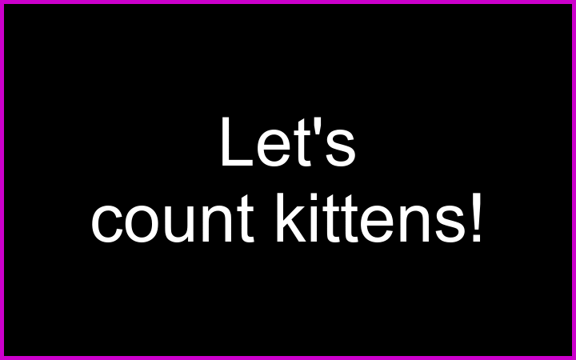

```r
library(magick)

# read and scale images to same size

kitten1 <- image_read("https://cdn.pixabay.com/photo/2022/05/21/09/30/cat-7211080__480.jpg") %>%
  image_scale(720)

kitten2 <- image_read("https://cdn.pixabay.com/photo/2018/06/29/10/49/cat-3505777__480.jpg") %>%
  image_crop(geometry_area(720, 450))

kitten3 <- image_read("https://cdn.pixabay.com/photo/2018/03/27/17/26/cat-3266675__480.jpg") %>%
  image_crop(geometry_area(720, 450))

kitten4 <- image_read("https://images.pexels.com/photos/12363189/pexels-photo-12363189.jpeg?auto=compress&cs=tinysrgb&w=800") %>%
  image_resize(geometry_size_pixels(720, 450, preserve_aspect = FALSE))

kitten5 <- image_read("https://images.pexels.com/photos/45170/kittens-cat-cat-puppy-rush-45170.jpeg?auto=compress&cs=tinysrgb&w=800") %>%
  image_resize(geometry_size_pixels(720, 450, preserve_aspect = FALSE))

kitten_images <- c(kitten1, kitten2, kitten3, kitten4, kitten5)

# setting up text for each frame

count <- 1:5 %>% as.character()

kitten_text <- c(paste(count[1], "kitten!"), paste(count[2:5], "kittens!"))

#constructing frames for animation

frame0 <- image_blank(710, 440, color = "#000000") %>%
  image_annotate(text = "Let's\ncount kittens!", size = 84, color = "#ffffff", gravity = "center") %>%
  image_border("#cc00cc", "5x5")

frame1 <- kitten_images[1] %>%
  image_annotate(text = kitten_text[1], size = 84, color = "#0099cc", strokecolor = "#000000", gravity = "north")

frame2 <- kitten_images[2] %>%
  image_annotate(text = kitten_text[2], size = 84, color = "#ff3399", strokecolor = "#000000", gravity = "north_west")

frame3 <- kitten_images[3] %>%
  image_annotate(text = kitten_text[3], size = 84, color = "#6699ff", strokecolor = "#ffffff", gravity = "north")

frame4 <- kitten_images[4] %>%
  image_annotate(text = kitten_text[4], size = 84, color = "#ff471a", strokecolor = "#000000", gravity = "north")

frame5 <- kitten_images[5] %>%
  image_annotate(text = kitten_text[5], size = 84, color = "#00ffff", strokecolor = "#000000", gravity = "south")

frames <- c(frame0, frame1, frame2, frame3, frame4, frame5)

# animate frames

kittens_animation <- image_animate(frames, delay = 120)

# saving as a gif

kittens_animation %>% image_write("my_animation.gif")
```

```css
@import url('https://fonts.googleapis.com/css2?family=Crimson+Text&display=swap');

body {background-color: #2e2e38; font-family: 'Crimson Text', serif; color: #f2f2f2}

h2 {font-size: 40px; padding: 10px; color: #ff4d4d}

p {font-size: 18px; padding: 10px}
```